# Selection question: AlexNet

## Implementation and optimization of a convolutional neural network

Implement a classic convolutional neural network: AlexNet. **Improve its efficiency as much as possible.** Your work will be evaluated by four aspects: *performance, algorithm design, software architecture and readability.*

- Neural network should be implemented by hand, open source arch(Caffe, Tensorflow, Theano, Torch) should not be used directly.
- Both inference and train algorithm should be constructed, performance should be well considered either.
- Project deadline: 2016-12-25

## Getting started

To achieve a easy start, I copied some useful code from [[1]](https://www.zybuluo.com/hanbingtao/note/476663) and [[2]](https://www.zybuluo.com/hanbingtao/note/485480), including:

- class Layer, class Node, class ConstNode, class Connection in fc_layer_hbt.py
- class ConvLayer in conv_layer.py

With the codes above, now we have the ability to:

- Construct a fully-connected layer instance with class Layer, forward calculation function not included in those classes
- Initialize a convolutional layer with class ConvLayer, including backpropagation algorithm and forward computation method

To achieve the goal mentioned at beginning, there exists several works to be finished:

- Design a network class, composing convolutional layer and fully-connected layer together. Both train and predict function should be implemented.
- Optimize the training and predicting procedure, improve performance of the network.

## Software architecture

### Inversion of Control

Before we design the network class, it might be wise to take a look at **alexnet.py** in tensorflow:

```python
net = slim.conv2d(inputs, 64, [11, 11], 4, padding='VALID',scope='conv1')
net = slim.max_pool2d(net, [3, 3], 2, scope='pool1')
net = slim.conv2d(net, 192, [5, 5], scope='conv2')
net = slim.max_pool2d(net, [3, 3], 2, scope='pool2')
net = slim.conv2d(net, 384, [3, 3], scope='conv3')
net = slim.conv2d(net, 384, [3, 3], scope='conv4')
net = slim.conv2d(net, 256, [3, 3], scope='conv5')
net = slim.max_pool2d(net, [3, 3], 2, scope='pool5')
```

Apparently, to make the procedure of network building looks more friendly, principle IoC was applied: instance net is passed to the constructor function of each layer-- my network class will learn from this to take more readability for the code:

```python
class Network(object):
    def __init__(self):
        self.layers = []

    def append_layer(self, layer):
        self.layers.append(layer)
```

Member variable **layers** will be initialized to hold layers in the network. Constructor method of layer will invoke the method *append_layer* to append themselves to the network.

### Training methods

As we all know, the training task of a neural network can be divided into three subtasks:

- Forward calculation, or model prediction: given input sample, calculate the output vector due to NN model
- Backpropagation-1: $\delta$ calculation of each layer. Acturally, $\delta_{l}$ is the partial derivative of the loss function $E_{d}$ on the weighted input vector $net_{l}$: $$\delta_{l}=\frac{\partial E_{d}}{\partial net_{l}}$$
- Backpropagation-2: calculate gradient matrix $\nabla$ for each layer, then update weight matrix $W$.

```python
    def train_one_sample(self, label, sample, rate):
        """
        train network with one sample
        """
        self.predict(sample)
        self.calc_delta(label)
        self.update_weight(rate)

    def calc_delta(self, label):
        """
        calc delta of each layer
        """
        output_layer = self.layers[-1]
        output_layer.calc_output_layer_delta(label)
        downstream_layer = output_layer
        for layer in self.layers[-2::-1]:
            layer.calc_layer_delta(downstream_layer)
            downstream_layer = layer

    def update_weight(self, rate):
        """
        update weights of each connection or filter
        """
        for layer in self.layers:
            layer.update_weight(rate)
    def predict(self, sample):
        """
        predict output according to input
        """
        self.layers[0].forward(sample)
        for i in range(1, len(self.layers)):
            self.layers[i].forward(self.layers[i-1].get_output())
        return self.layers[-1].get_output()
```

Obviously, some interface method should be implemented in each layer class: *forward*, *calc_layer_delta*, *update_weight*.

### Redesign of fully-connected layer

I need to redesign the fully-connected layer class, for those reasons:

- Fully-connected layers implemented with Node and Connection objects will encounter a great problem when docking with convolutional layer copied from hanbingtao.
- Layers with large amount of nodes takes large memory storing their Node and Connection objects. Besides, I'm afraid that efficiency problem will be caused when executing large-scale NN backpropagation algorithm with codes we have.

To take advantage of numpy's matrix calculation ability, I will implement methods in fc layer using matrix operation.

```python
import numpy as np

class FcLayer(object):
    def __init__(self, network, node_count, activator):
        self.output_array = np.zeros([node_count])
        self.bias_array = np.zeros([node_count])
        input_shape = network.layers[-1].get_output().shape
        self.input_1dim = reduce(lambda ret, dim: ret * dim, input_shape, 1)
        self.trans_matrix = np.random.uniform(0.1, 0.3, [node_count, self.input_1dim])
        self.activator = activator
        network.append_layer(self)
```

- *output_array*: output vector of a fc layer
- *bias_array*: bias unit(or bias vector) of current layer
- *input_1dim*: total number of the input(1D,2D,3D), useful for adapt convolutional layer's output to fully-connected layer's input
- *trans_matrix*: transform matrix used to transform input array into output array
- *activator*: activator function for output, ReLU was chosen in alexnet.

Let $W$ represent transform matrix, $\vec x$ as input vector, $\vec b$ as bias unit, $\vec a$ as output vector, $f$ as activator function:

$$ W=\left[ \begin{matrix} w_{11} & w_{12} & \cdots & w_{1m} \\ w_{21} & w_{22} & \cdots & w_{2m} \\ \vdots & \vdots & \ddots & \vdots \\ w_{n1} & w_{n2} & \cdots & w_{nm} \\ \end{matrix} \right] ,\quad \vec x=\left[ \begin{matrix} x_{1} \\ x_{2} \\ \vdots \\ x_{m} \\ \end{matrix} \right] ,\quad \vec b=\left[ \begin{matrix} b_{1} \\ b_{2} \\ \vdots \\ b_{n} \\ \end{matrix} \right] ,\quad \vec a=\left[ \begin{matrix} a_{1} \\ a_{2} \\ \vdots \\ a_{n} \\ \end{matrix} \right] ,\quad f( \left[ \begin{matrix} x_{1} \\ x_{2} \\ \vdots \\ x_{n} \\ \end{matrix} \right] )=\left[ \begin{matrix} f(x_{1}) \\ f(x_{2}) \\ \vdots \\ f(x_{n}) \\ \end{matrix} \right] $$

We will get equation like: $$\vec a=f(W \cdot \vec x + \vec b)$$

Then the fully-connected layer's prediction procedure should be implemented as:

```python
def forward(self, input_array):
        self.input_array = input_array.reshape(self.input_1dim)
        self.output_array = np.dot(self.trans_matrix, self.input_array) + self.bias_array
        self.output_array = np.array([self.activator.forward(value) for value in self.output_array])
```

The reason reshaping the input array is, it's neccessary to adapt input array to 1-D when accepting 3D-input from convolutional layer.

There exist two cases to be considered when calculating $\delta$ of each layer: $\delta$ of output layer and non-output layer:

$$\vec \delta_{output}=\vec y'*(\vec t-\vec y)$$$$\vec \delta_{non-output}=\vec a'*(W_{downstream}^{T}\cdot \vec \delta_{downstream})$$

Methods implement:

```python
def calc_output_layer_delta(self, label):
        derivative = np.array([self.activator.backward(out) for out in self.output_array])
        self.delta_array = derivative * (label - self.output_array)

def calc_layer_delta(self, downstream_layer):
        derivative = np.array([self.activator.backward(out) for out in self.output_array])
        self.delta_array = derivative * downstream_layer.get_transformed_delta()
def get_transformed_delta(self):
        return np.dot(self.trans_matrix.transpose(), self.delta_array)
```

Next we can update transform matrix and bias vector of each layer with equations:

$$W\leftarrow W + \eta*\vec \delta \cdot \vec x^{T}$$$$\vec b \leftarrow \vec b + \eta * \vec \delta$$

Methods implement:

```python
def update_weight(self, rate):
        self.trans_matrix += rate * np.dot(self.delta_array.reshape([len(self.delta_array),1]),\
                                           self.input_array.reshape([1, self.input_1dim]))
        self.bias_array += rate * self.delta_array
```

For now, my new fully-connected layer class has got the ability to finish a complete training procedure.

### Supplement of convolutional layer class

With some little adjustment and supplement, code in conv_layer.py(copied from [[2]](https://www.zybuluo.com/hanbingtao/note/485480)) should dock well with fully-connected layer class above.

First we need to implement a missed method called *get_patch*, which will return a specified slice from given 2D or 3D array:

```python
def get_patch(input_array, i, j, kernel_width, kernel_height, stride):
    if len(input_array.shape) > 2:
        return input_array[:, i*stride:i*stride+kernel_width, j*stride:j*stride+kernel_height]
    return input_array[i*stride:i*stride+kernel_width, j*stride:j*stride+kernel_height]
```

For the purpose of fitting with *network.py*, two interface method should be implemented(*forward* already prepared): *calc_layer_delta*, *update_weight*:

```python
def calc_layer_delta(self, downstream_layer):
    downstream_delta = downstream_layer.get_transformed_delta().reshape(self.output_array.shape)
    self.bp_sensitivity_map(downstream_delta, self.activator)

def update_weight(self, rate):
    self.learning_rate = rate
    self.bp_gradient(self.current_layer_delta_array)
    self.update()
```

### Constructor improvement

Obviously, it seems a bit foolish to give the input size every time create a new convolutional layer--- we can get the input size from previous layer's output except first layer. We may create a class inherit from convolutional layer:

```python
class ConvLayerHidden(ConvLayer):
    def __init__(self, network, filter_width,
                 filter_height, filter_number,
                 zero_padding, stride, activator,
                 learning_rate):
        upstream_layer = network.layers[-1]
        input_width = upstream_layer.get_output().shape[1]
        input_height = upstream_layer.get_output().shape[2]
        channel_number = upstream_layer.get_output().shape[0]
        ConvLayer.__init__(self, network, input_width, input_height,
                           channel_number, filter_width,
                           filter_height, filter_number,
                           zero_padding, stride, activator,
                           learning_rate)
```

Then the procedure of creating network should act like:

```python
net = Network()

ConvLayer(net, 50, 50, 3, 11, 11, 48, 2, 4, Relu(), 0.05)
ConvLayerHidden(net, 3, 3, 24, 2, 3, Relu(), 0.05)
FcLayer(net, 5, Relu())
FcLayer(net, 10, Relu())
```

### Dropout layer

To prevent overfitting, **dropout layer** was applied before fully-connected layer or softmax layer in alexnet. Without dropout layer, fully-connected layer will act like:

$$\vec a=W \cdot \vec x + \vec b$$

where $\vec x$ represents input of layer and $\vec a$ represents output. When dropout been applied, equation will act like:

$$\vec r = Bernoulli(prob)$$$$\widetilde x = \vec r * \vec x$$$$\vec a=W \cdot \widetilde x + \vec b$$

Thus, implementation of dropout layer will be:

```python
def __init__(self, network, dropout_prob=0.5):
        self.dropout_prob = dropout_prob
        input_array = network.layers[-1].get_output()
        self.output_array = np.zeros(input_array.shape)
        network.append_layer(self)

    def forward(self, input_array, training=False):
        if training:
            retain_prob = 1. - self.dropout_prob
            self.dropout_array = np.random.binomial(1, retain_prob, size=input_array.shape)
            self.output_array = input_array * self.dropout_array / retain_prob
        else:
            self.output_array = input_array / self.dropout_prob

    def get_output(self):
        return self.output_array

    def calc_layer_delta(self, downstream_layer):
        self.delta_array = downstream_layer.get_transformed_delta() * self.dropout_array
```

### Softmax layer

Equation of softmax function is:

$$a_{j}^{L}=\frac{e^{z_{j}^{l}}}{\sum_{k}e^{z_{k}^{l}}}$$

where $z_{j}^{l}$ represents the weighted input of neuron $j$ in layer $l$, $a_{j}^{L}$ represent the output of neuron $j$ in layer $l$. To get partial derivative $\frac{\partial a_{j}}{\partial z_{i}}$, two cases should be considered:

if $j=i:$ $$\frac{\partial a_{j}}{\partial z_{i}}=\frac{\partial}{\partial z_{i}}(\frac{e^{z_{j}}}{\sum_{k}e^{z_{k}}})=\frac{(e^{z_{j}})' \cdot \sum_{k}e^{z_{k}} - e^{z_{j}} \cdot e^{z_{j}}}{(\sum_{k}e^{z_{k}})^{2}}=\frac{e^{z_{j}}}{\sum_{k}e^{z_{k}}}-\frac{e^{z_{j}}}{\sum_{k}e^{z_{k}}} \cdot \frac{e^{z_{j}}}{\sum_{k}e^{z_{k}}}=a_{j}(1-a_{j})$$ if $j \neq i:$ $$\frac{\partial a_{j}}{\partial z_{i}}=\frac{\partial}{\partial z_{i}}(\frac{e^{z_{j}}}{\sum_{k}e^{z_{k}}})=\frac{0 \cdot \sum_{k}e^{z_{k}} - e^{z_{j}} \cdot e^{z_{i}}}{(\sum_{k}e^{z_{k}})^{2}}=-\frac{e^{z_{j}}}{\sum_{k}e^{z_{k}}} \cdot \frac{e^{z_{i}}}{\sum_{k}e^{z_{k}}}=-a_{j}a_{i}$$

Instead of cross entropy loss, I use logistic as the cost function below.:

$$C=- \sum_{k}y_{k}\log a_{k}$$

Compared with cross entropy loss, this will work either, and the most important reason I choose that is: the ultimate format of $\delta$ looks much more simple:

$$\frac{\partial C}{\partial b_{j}}=\frac{\partial C}{\partial z_{j}} \cdot \frac{\partial z_{j}}{\partial b_{j}}=\frac{\partial C}{\partial z_{j}} \cdot \frac{\partial (w_{jk}a_{k}+b_{j})}{\partial b_{j}}=\frac{\partial}{\partial z_{j}}(-\sum_{k} y_{k} \log a_{k})=-y_{j} \frac{1}{a_{j}} \cdot \frac{\partial a_{j}}{\partial z_{j}}-\sum_{k \neq j}y_{k} \frac{1}{a_{k}} \cdot \frac{\partial a_{k}}{\partial z_{j}}=-y_{j} \frac{1}{a_{j}} \cdot a_{j}(1-a_{j})-\sum_{k \neq j}y_{k} \frac{1}{a_{k}} \cdot (-a_{j}a_{k})=-y_{j}+y_{j}a_{j}+\sum_{k \neq j}y_{k}a_{j}=-y_{j}+a_{j}\sum_{k}y_{k}=a_{j}-y_{j}$$$$\frac{\partial C}{\partial w_{jk}}=a_{k}^{L-1}(a_{j}^{L}-y_{j})$$

Code lists below:

```python
class SoftmaxLayer(FcLayer):

    def __init__(self, network, node_count):
        FcLayer.__init__(self, network, node_count, Softmax())

    def forward(self, input_array, training=False):
        self.input_array = input_array.reshape(self.input_1dim)
        self.output_array = np.dot(self.trans_matrix, self.input_array) + self.bias_array
        self.output_array = self.activator.forward(self.output_array)

    def calc_output_layer_delta(self, label):
        self.delta_array = self.output_array - label

    def update_weight(self, rate):
        self.trans_matrix -= rate * np.dot(self.delta_array.reshape([len(self.delta_array),1]),
                                           self.input_array.reshape([1, self.input_1dim]))
        self.bias_array -= rate * self.delta_array
```

### Max pooling layer

Compared with fully-connected layer and convolutional layer, max-pooling layer is much more easier to be realized. Here I copied the code of max pooling layer from [[2]](https://www.zybuluo.com/hanbingtao/note/485480), then implement some interface methods:

```python
def get_output(self):
    return self.output_array

def get_transformed_delta(self):
    return self.delta_array

def update_weight(self, rate):
    pass
```

Some adjustment need to be made to method *backward*:

```python
def calc_layer_delta(self, downstream_layer):
        self.delta_array = np.zeros(self.input_array.shape)
        sensitivity_array = downstream_layer.get_transformed_delta().reshape(self.output_array.shape)
        for d in range(self.channel_number):
            for i in range(self.output_height):
                for j in range(self.output_width):
                    patch_array = get_patch(
                        self.input_array[d], i, j,
                        self.filter_width,
                        self.filter_height,
                        self.stride)
                    k, l = get_max_index(patch_array)
                    self.delta_array[d,
                                     i * self.stride + k,
                                     j * self.stride + l] = \
                        sensitivity_array[d, i, j]
```

### Local response normalization layer

When a neuron been activated, other neurons on adjacent channels should be inhibited. That's the usage of LRN layer in alexnet, the forward equation is:

$$u_{i}=k+\alpha \sum_{j=max(0,i-n/2}^{min(N-1,i+n/2)}a_{j}^{2}$$$$b_{i}=a_{i}(u_{i})^{-\beta}$$

Code implementation:

```python
class LrnLayer(object):
    def __init__(self, network, k, alpha, n, beta):
        self.input_array = network.layers[-1].get_output()
        self.k = k
        self.alpha = alpha
        self.n = n
        self.beta = beta
        self.output_array = np.zeros(self.input_array.shape)
        network.append_layer(self)

    def forward(self, input_array, training=False):
        self.input_array = input_array
        self.normalize_matrix = np.zeros(input_array.shape)
        for i in range(0, input_array.shape[0]):
            sum_matrix = np.zeros([input_array.shape[1], input_array.shape[2]])
            for j in range(max(0, i-self.n/2), min(self.input_array.shape[0]-1, i+self.n/2)):
                sum_matrix += input_array[j,:,:] ** 2
            self.normalize_matrix[i, :, :] = self.k + self.alpha * sum_matrix
        self.divisor_matrix = self.normalize_matrix ** (-self.beta)
        self.output_array = self.input_array * self.divisor_matrix
```

When deriving the derivative of $b_{j}$ towards $a_{i}$, two cases need to be considered:

if $j=i:$ $$\frac{\partial b_{j}}{\partial a_{i}}=\frac{\partial}{\partial a_{i}}[a_{i}(u_{i})^{-\beta}]=u_{i}^{-\beta}-a_{i}\beta u_{i}^{-\beta-1}2\alpha a_{i}=u_{i}^{-\beta}-2\alpha\beta a_{i}b_{i}u_{i}^{-1}$$ if $j \neq i:$ $$\frac{\partial b_{j}}{\partial a_{i}}=\frac{\partial}{\partial a_{i}}[a_{j}(u_{j})^{-\beta}]=-2\alpha\beta a_{i}b_{j}u_{j}^{-1}$$

Then the $\delta$ passing formula should be:

$$\delta_{i}^{a}=\sum_{j=max(0,i-n/2}^{min(N-1,i+n/2)} \delta_{j}^{b}\cdot\frac{\partial b_{j}}{\partial a_{i}}=u_{i}^{-\beta}\delta_{i}^{b}-2\alpha\beta a_{i}\sum_{j=max(0,i-n/2)}^{min(N-1,i+n/2)}b_{j}\delta_{j}^{b}u_{j}^{-1}$$

Code implementation:

```python
def calc_layer_delta(self, downstream_layer):
        delta_array_downstream = downstream_layer.get_transformed_delta()
        self.delta_array = np.zeros(downstream_layer.get_transformed_delta().shape)
        for i in range(0, self.delta_array.shape[0]):
            sum_matrix = np.zeros([self.delta_array.shape[1], self.delta_array.shape[2]])
            for j in range(max(0, i - self.n / 2), min(self.input_array.shape[0] - 1, i + self.n / 2)):
                sum_matrix += self.output_array[j,:,:] * delta_array_downstream[j,:,:] \
                                / self.normalize_matrix[j,:,:]
            self.delta_array[i,:,:] = self.divisor_matrix[i,:,:] * delta_array_downstream[i,:,:] - \
                                      2 * self.alpha * self.beta * self.input_array[i,:,:] * sum_matrix
```

### A simple dock test

For now, we have implement all kind of layers used to dock a alexnet: fully-connected layer, convolutional layer, lrn layer, dropout layer, max-pooling layer and softmax layer. Next we may dock them together and test the convergence property of the simple network:

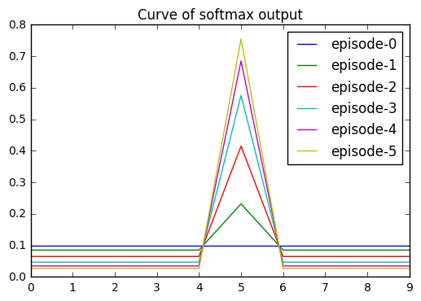

```python
import numpy as np
from python.layers.conv_layer import ConvLayer
from python.layers.conv_layer_hidden import ConvLayerHidden
from python.layers.fc_layer import FcLayer
from python.layers.lrn_layer import LrnLayer
from python.layers.max_pooling_layer import MaxPoolingLayer
from python.layers.softmax_layer import SoftmaxLayer
from python.utils.sci_plotter import SciPlot

from python.layers.dropout_layer import DropoutLayer
from python.network.network import Network
from python.utils.activator import ReluActivator as Relu
if __name__ == '__main__':
    fake_image = np.random.uniform(0, 255, [3, 25, 25])
    fake_label = np.zeros([10])
    fake_label[5] = 1
    net = Network()

    sp = SciPlot('Curve of softmax output')
    ConvLayer(net, 25, 25, 3, 11, 11, 48, 2, 4, Relu(), 0.05)
    LrnLayer(net, 2, 0.0001, 5, 0.75)
    MaxPoolingLayer(net, 3, 3, 2)

    FcLayer(net, 5, Relu())
    DropoutLayer(net,dropout_prob=0.5)
    SoftmaxLayer(net, 10)

    sp.plot(net.predict(fake_image, training=False), desc='episode-' + str(0))
    for i in range(0, 5):
        net.train_one_sample(fake_label, fake_image, 1, showlog=False)
        sp.plot(net.predict(fake_image, training=False), desc='episode-'+str(i+1))

    sp.show()
```

According to the experiment result above, the network consist of 6 different kind of layers works well: the bias of network's predict result get lower after each episode.

## Performance optimization

### Original performance of alexnet

First, let's implement a real-size alexnet using layers built above:

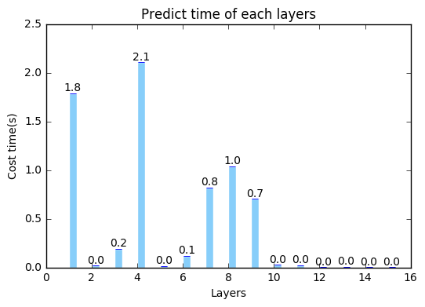

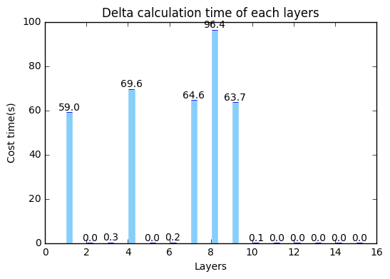

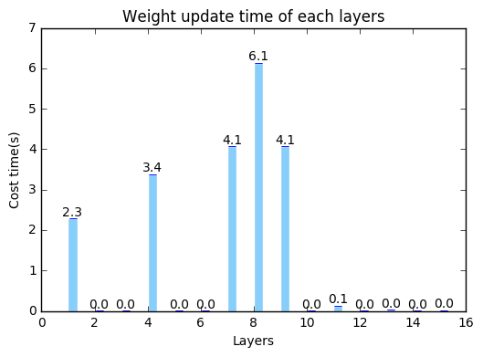

```python
import numpy as np
from python.layers.conv_layer import ConvLayer
from python.layers.conv_layer_hidden import ConvLayerHidden
from python.layers.fc_layer import FcLayer
from python.layers.lrn_layer import LrnLayer
from python.layers.max_pooling_layer import MaxPoolingLayer
from python.layers.softmax_layer import SoftmaxLayer
from python.utils.sci_plotter import SciPlot
from scipy import misc

from python.layers.dropout_layer import DropoutLayer
from python.network.network import Network
from python.utils.activator import ReluActivator as Relu

if __name__ == '__main__':
    raccoon_image = misc.imread('./res/face.png').reshape([3,224,224])
    label = np.zeros([1000])
    label[0] = 1
    net = Network()

    ConvLayer(net, 224, 224, 3, 11, 11, 96, 2, 4, Relu(), 0.05)
    LrnLayer(net, 2, 0.0001, 5, 0.75)
    MaxPoolingLayer(net, 3, 3, 2)

    ConvLayerHidden(net, 5, 5, 256, 2, 1, Relu(), 0.05)
    LrnLayer(net, 2, 0.0001, 5, 0.75)
    MaxPoolingLayer(net, 3, 3, 2)

    ConvLayerHidden(net, 3, 3, 384, 1, 1, Relu(), 0.05)

    ConvLayerHidden(net, 3, 3, 384, 1, 1, Relu(), 0.05)

    ConvLayerHidden(net, 3, 3, 256, 1, 1, Relu(), 0.05)
    MaxPoolingLayer(net, 3, 3, 2)

    FcLayer(net, 2048, Relu())
    DropoutLayer(net, dropout_prob=0.5)

    FcLayer(net, 2048, Relu())
    DropoutLayer(net)

    SoftmaxLayer(net, 1000)

    net.train_one_sample(label, raccoon_image, 1, showlog=False)
    sp = SciPlot('Predict time of each layers')
    sp.bar(net.indexes, net.predict_time)
    sp.show()
    sp = SciPlot('Delta calculation time of each layers')
    sp.bar(net.indexes, net.delta_calc_time)
    sp.show()
    sp = SciPlot('Weight update time of each layers')
    sp.bar(net.indexes, net.update_weight_time)
    sp.show()
```

Obviously, it's the convolutional layer that costs most of time doing forward calculation, delta calculation and weight updating. So we should make more effort on convolutional layer to improve the performance of alexnet.

### Two ways of improve the performance

To improve the performance, there are **two basic ideas**: *reduce cost time of the training procedure*, or *adjust "stride" of each episode's weight update* in order to reduce the times training alexnet to a fixed bias.

### Momentum SGD

Inspired by momentum theorem in physics, momentus sgd is applied to amplify the weight gradient of each episode in order to reduce training times of the network:

$$\nabla_{i}(t+1)=-\eta \frac{\partial E}{\partial w_{i}} + \alpha \nabla_{i}(t)$$

Code adjustment in fully-connected layer, softmax layer and convolutional layer:

```python
class FcLayer(object):
    def update_weight(self, rate):
        trans_gradient = np.dot(self.delta_array.reshape([len(self.delta_array),1]),
                                self.input_array.reshape([1, self.input_1dim]))
        bias_gradient = self.delta_array
        self.trans_matrix += rate * trans_gradient + self.momentum_rate * self.trans_gradient_cache
        self.bias_array += rate * bias_gradient + self.momentum_rate * self.bias_gradient_cache
        self.trans_gradient_cache = trans_gradient
        self.bias_gradient_cache = bias_gradient
```

```python
class SoftmaxLayer(FcLayer):
    def update_weight(self, rate):
        trans_gradient = np.dot(self.delta_array.reshape([len(self.delta_array),1]),
                                self.input_array.reshape([1, self.input_1dim]))
        bias_gradient = self.delta_array
        self.trans_matrix += rate * trans_gradient + self.momentum_rate * self.trans_gradient_cache
        self.bias_array += rate * bias_gradient + self.momentum_rate * self.bias_gradient_cache
        self.trans_gradient_cache = trans_gradient
        self.bias_gradient_cache = bias_gradient
```

```python
class Filter(object):
    def __init__(self, width, height, depth):
        self.weights = np.random.uniform(-1e-4, 1e-4,
                                         (depth, height, width))
        self.bias = 0
        self.weights_grad = np.zeros(self.weights.shape)
        self.weights_grad_cache = np.zeros(self.weights.shape)
        self.bias_grad = 0
        self.bias_grad_cache = 0

    def __repr__(self):
        return 'filter weights:\n%s\nbias:\n%s' % (
            repr(self.weights), repr(self.bias))

    def get_weights(self):
        return self.weights

    def get_bias(self):
        return self.bias

    def update(self, learning_rate, momentum_rate):
        self.weights -= learning_rate * self.weights_grad + momentum_rate * self.weights_grad_cache
        self.bias -= learning_rate * self.bias_grad + momentum_rate * self.bias_grad_cache
        self.weights_grad_cache = self.weights_grad
        self.bias_grad_cache = self.bias_grad
```

Here is a comparative experiment:

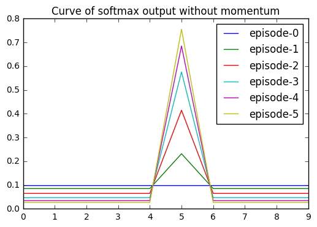

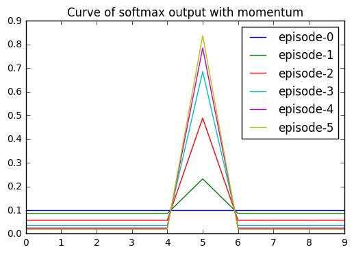

```python
import numpy as np
from python.layers.conv_layer import ConvLayer
from python.layers.conv_layer_hidden import ConvLayerHidden
from python.layers.fc_layer import FcLayer
from python.layers.lrn_layer import LrnLayer
from python.layers.max_pooling_layer import MaxPoolingLayer
from python.layers.softmax_layer import SoftmaxLayer
from python.utils.sci_plotter import SciPlot

from python.layers.dropout_layer import DropoutLayer
from python.network.network import Network
from python.utils.activator import ReluActivator as Relu
if __name__ == '__main__':
    fake_image = np.random.uniform(0, 255, [3, 25, 25])
    fake_label = np.zeros([10])
    fake_label[5] = 1
    net = Network()

    sp = SciPlot('Curve of softmax output without momentum')
    ConvLayer(net, 25, 25, 3, 11, 11, 48, 2, 4, Relu(), 0.05)
    LrnLayer(net, 2, 0.0001, 5, 0.75)
    MaxPoolingLayer(net, 3, 3, 2)

    FcLayer(net, 5, Relu())
    DropoutLayer(net,dropout_prob=0.5)
    SoftmaxLayer(net, 10)

    sp.plot(net.predict(fake_image, training=False), desc='episode-' + str(0))
    for i in range(0, 5):
        net.train_one_sample(fake_label, fake_image, 1, showlog=False)
        sp.plot(net.predict(fake_image, training=False), desc='episode-'+str(i+1))

    sp.show()

    net = Network()

    sp = SciPlot('Curve of softmax output with momentum')
    ConvLayer(net, 25, 25, 3, 11, 11, 48, 2, 4, Relu(), 0.05, momentum_rate=0.3)
    LrnLayer(net, 2, 0.0001, 5, 0.75)
    MaxPoolingLayer(net, 3, 3, 2)

    FcLayer(net, 5, Relu(), momentum_rate=0.3)
    DropoutLayer(net,dropout_prob=0.5)
    SoftmaxLayer(net, 10, momentum_rate=0.3)

    sp.plot(net.predict(fake_image, training=False), desc='episode-' + str(0))
    for i in range(0, 5):
        net.train_one_sample(fake_label, fake_image, 1, showlog=False)
        sp.plot(net.predict(fake_image, training=False), desc='episode-'+str(i+1))

    sp.show()
```

Obviously, the second curve plot, which represent the output of network with a 0.3 momentum rate achieve almost 0.7 in episode 3, while network without momentum only got 0.6. So the optimization is valid.

### Convert convolution calculation to matrix multiplication

From the bar chart showed above, it's obvious that convolutional layer wins the grand slam of best time-stealer: operation 'conv' takes so much time that all the predicting, delta calculating and weight updating procedure consumes major of time.

To improve the performance of 'conv' operation, we can use matrix multiplication instead of plenty multiplication and sum operation of integers. Specifically, both filters and 'filtered inputs' should be reshape to a 2-D matrix, then convolution calculation should be convert to matrix multiplication. Procedure showing below:

[figure not shown]

The code of matrix-version convolution calculation lists below:

```python
def conv_matrix_3d(input_array,
                kernel_array,
                kernel_width,
                kernel_height,
                output_array,
                stride, bias):
    """
    calculate convolution for 3D
    """
    channel_number = input_array.ndim
    output_width = output_array.shape[2]
    output_height = output_array.shape[1]
    input_transform = np.zeros((output_height * output_width, kernel_array.shape[0]))
    for i in range(output_height):
        for j in range(output_width):
            input_transform[j + output_height * i, :] = get_patch(input_array, i, j, kernel_width, kernel_height,
                                                                  stride).reshape(kernel_array.shape[0])
    output_array_transform = np.dot(input_transform, kernel_array) + bias

    return output_array_transform.reshape(output_array.shape)


def conv_matrix_2d(input_array,
                   kernel_array,
                   kernel_width,
                   kernel_height,
                   output_array,
                   stride, bias):
    """
    calculate convolution for 2D
    """
    channel_number = input_array.ndim
    output_width = output_array.shape[1]
    output_height = output_array.shape[0]
    input_transform = np.zeros((output_height * output_width, kernel_array.shape[0]))
    for i in range(output_height):
        for j in range(output_width):
            input_transform[j + output_height * i, :] = get_patch(input_array, i, j, kernel_width, kernel_height,
                                                                  stride).reshape(kernel_array.shape[0])
    output_array_transform = np.dot(input_transform, kernel_array) + bias

    return output_array_transform.reshape(output_array.shape)
```

Next I'll do a comparative experiment to verify the performance of the new algorithm:

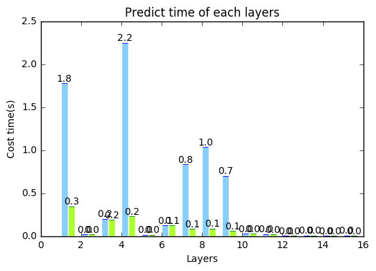

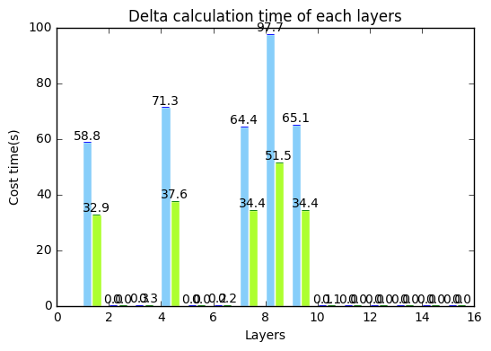

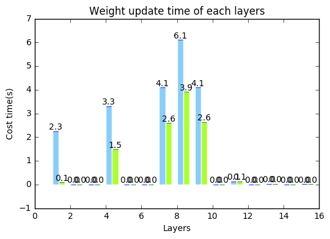

```python
import numpy as np
from python.layers.conv_layer import ConvLayer
from python.layers.conv_layer_hidden import ConvLayerHidden
from python.layers.conv_layer_matrix import ConvLayer as ConvLayerMatrix
from python.layers.conv_layer_matrix_hidden import ConvLayerHidden as ConvLayerMatrixHidden
from python.layers.fc_layer import FcLayer
from python.layers.lrn_layer import LrnLayer
from python.layers.max_pooling_layer import MaxPoolingLayer
from python.layers.softmax_layer import SoftmaxLayer
from python.utils.sci_plotter import SciPlot
from scipy import misc

from python.layers.dropout_layer import DropoutLayer
from python.network.network import Network
from python.utils.activator import ReluActivator as Relu

if __name__ == '__main__':
    raccoon_image = misc.imread('./res/face.png').reshape([3,224,224])
    label = np.zeros([1000])
    label[0] = 1

    net = Network()

    ConvLayer(net, 224, 224, 3, 11, 11, 96, 2, 4, Relu(), 0.05)
    LrnLayer(net, 2, 0.0001, 5, 0.75)
    MaxPoolingLayer(net, 3, 3, 2)

    ConvLayerHidden(net, 5, 5, 256, 2, 1, Relu(), 0.05)
    LrnLayer(net, 2, 0.0001, 5, 0.75)
    MaxPoolingLayer(net, 3, 3, 2)

    ConvLayerHidden(net, 3, 3, 384, 1, 1, Relu(), 0.05)

    ConvLayerHidden(net, 3, 3, 384, 1, 1, Relu(), 0.05)

    ConvLayerHidden(net, 3, 3, 256, 1, 1, Relu(), 0.05)
    MaxPoolingLayer(net, 3, 3, 2)

    FcLayer(net, 2048, Relu())
    DropoutLayer(net, dropout_prob=0.5)

    FcLayer(net, 2048, Relu())
    DropoutLayer(net)

    SoftmaxLayer(net, 1000)

    net1 = Network()

    ConvLayerMatrix(net1, 224, 224, 3, 11, 11, 96, 2, 4, Relu(), 0.05)
    LrnLayer(net1, 2, 0.0001, 5, 0.75)
    MaxPoolingLayer(net1, 3, 3, 2)

    ConvLayerMatrixHidden(net1, 5, 5, 256, 2, 1, Relu(), 0.05)
    LrnLayer(net1, 2, 0.0001, 5, 0.75)
    MaxPoolingLayer(net1, 3, 3, 2)

    ConvLayerMatrixHidden(net1, 3, 3, 384, 1, 1, Relu(), 0.05)

    ConvLayerMatrixHidden(net1, 3, 3, 384, 1, 1, Relu(), 0.05)

    ConvLayerMatrixHidden(net1, 3, 3, 256, 1, 1, Relu(), 0.05)
    MaxPoolingLayer(net1, 3, 3, 2)

    FcLayer(net1, 2048, Relu())
    DropoutLayer(net1, dropout_prob=0.5)

    FcLayer(net1, 2048, Relu())
    DropoutLayer(net1)

    SoftmaxLayer(net1, 1000)

    net.train_one_sample(label, raccoon_image, 1, showlog=False)
    net1.train_one_sample(label, raccoon_image, 1, showlog=False)
    sp = SciPlot('Predict time of each layers')
    sp.bar(net.indexes, net.predict_time)
    sp.bar(net1.indexes + 0.35, net1.predict_time, color='greenyellow')
    sp.show()
    sp = SciPlot('Delta calculation time of each layers')
    sp.bar(net.indexes, net.delta_calc_time)
    sp.bar(net1.indexes + 0.35, net1.delta_calc_time, color='greenyellow')
    sp.show()
    sp = SciPlot('Weight update time of each layers')
    sp.bar(net.indexes, net.update_weight_time)
    sp.bar(net1.indexes + 0.35, net1.update_weight_time, color='greenyellow')
    sp.show()
```

*Fantastic improvement!*

## Other optimization

### Weight decay

To prevent overfitting, alexnet using weight decay when updating weights, and usually it works well with momentum sgd mentioned above:

$$\nabla_{i}(t+1)=-\eta \frac{\partial E}{\partial w_{i}} + \alpha \nabla_{i}(t)-\lambda \eta w_{i}$$

Code adjustment:

```python
class FcLayer(object):
    def update_weight(self, rate):
        trans_gradient = np.dot(self.delta_array.reshape([len(self.delta_array),1]),
                                self.input_array.reshape([1, self.input_1dim]))
        bias_gradient = self.delta_array
        self.trans_matrix += rate * trans_gradient + self.momentum_rate * self.trans_gradient_cache \
                                - rate * self.decay_rate * self.trans_matrix
        self.bias_array += rate * bias_gradient + self.momentum_rate * self.bias_gradient_cache \
                                - rate * self.decay_rate * self.bias_array
        self.trans_gradient_cache = trans_gradient
        self.bias_gradient_cache = bias_gradient
```

```python
class SoftmaxLayer(FcLayer):
    def update_weight(self, rate):
        trans_gradient = np.dot(self.delta_array.reshape([len(self.delta_array),1]),
                                self.input_array.reshape([1, self.input_1dim]))
        bias_gradient = self.delta_array
        self.trans_matrix += rate * trans_gradient + self.momentum_rate * self.trans_gradient_cache \
                            - rate * self.decay_rate * self.trans_matrix
        self.bias_array += rate * bias_gradient + self.momentum_rate * self.bias_gradient_cache \
                            - rate * self.decay_rate * self.bias_array
        self.trans_gradient_cache = trans_gradient
        self.bias_gradient_cache = bias_gradient
```

```python
class Filter(object):
    def update(self, learning_rate, momentum_rate, decay_rate):
        self.weights -= learning_rate * self.weights_grad + momentum_rate * self.weights_grad_cache \
                        - learning_rate * decay_rate * self.weights
        self.bias -= learning_rate * self.bias_grad + momentum_rate * self.bias_grad_cache \
                        - learning_rate * decay_rate * self.bias
        self.weights_grad_cache = self.weights_grad
        self.bias_grad_cache = self.bias_grad
```

Here is a comparative experiment:

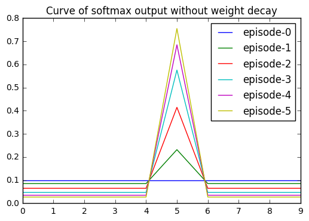

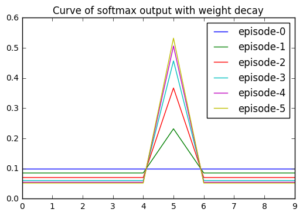

```python
import numpy as np
from python.layers.conv_layer import ConvLayer
from python.layers.conv_layer_hidden import ConvLayerHidden
from python.layers.fc_layer import FcLayer
from python.layers.lrn_layer import LrnLayer
from python.layers.max_pooling_layer import MaxPoolingLayer
from python.layers.softmax_layer import SoftmaxLayer
from python.utils.sci_plotter import SciPlot

from python.layers.dropout_layer import DropoutLayer
from python.network.network import Network
from python.utils.activator import ReluActivator as Relu
if __name__ == '__main__':
    fake_image = np.random.uniform(0, 255, [3, 25, 25])
    fake_label = np.zeros([10])
    fake_label[5] = 1
    net = Network()

    sp = SciPlot('Curve of softmax output without weight decay')
    ConvLayer(net, 25, 25, 3, 11, 11, 48, 2, 4, Relu(), 0.05)
    LrnLayer(net, 2, 0.0001, 5, 0.75)
    MaxPoolingLayer(net, 3, 3, 2)

    FcLayer(net, 5, Relu())
    DropoutLayer(net,dropout_prob=0.5)
    SoftmaxLayer(net, 10)

    sp.plot(net.predict(fake_image, training=False), desc='episode-' + str(0))
    for i in range(0, 5):
        net.train_one_sample(fake_label, fake_image, 1, showlog=False)
        sp.plot(net.predict(fake_image, training=False), desc='episode-'+str(i+1))

    sp.show()

    net = Network()

    sp = SciPlot('Curve of softmax output with weight decay')
    ConvLayer(net, 25, 25, 3, 11, 11, 48, 2, 4, Relu(), 0.05, decay_rate=0.2)
    LrnLayer(net, 2, 0.0001, 5, 0.75)
    MaxPoolingLayer(net, 3, 3, 2)

    FcLayer(net, 5, Relu(), decay_rate=0.2)
    DropoutLayer(net,dropout_prob=0.5)
    SoftmaxLayer(net, 10, decay_rate=0.2)

    sp.plot(net.predict(fake_image, training=False), desc='episode-' + str(0))
    for i in range(0, 5):
        net.train_one_sample(fake_label, fake_image, 1, showlog=False)
        sp.plot(net.predict(fake_image, training=False), desc='episode-'+str(i+1))

    sp.show()
```

From the curve plots above, it's obviously that network with weight decay will converge at a lower level than that without weight decay, thus avoid the situation of low bias& high variance, or overfitting.